# PLASTIC POLLUTION

a look into causes and relations

Author

Affiliation

[Lane Andreas](https://example.com/)

[University of Arizona](https://azcast.arizona.edu)

Published

May 8, 2023

Abstract

## 1 Review of the literature

Plastic pollution has become one of the most pressing environmental issues of our time, with its impacts being felt across the globe. According to a study published in Waste Management by Kumar et al. (Kumar et al., 2018), the plastic waste generated in the study area in Dhanbad, India was found to be 5.7% of the total municipal solid waste. The study established a relationship between plastic waste generation rate and the identified socioeconomic groups: higher socioeconomic group (HSEG), middle socioeconomic group (MSEG), and lower socioeconomic group (LSEG) of the study area. The study found that HSEG had the maximum plastic waste generation rate of 51 g/c/d, while LSEG had the minimum plastic waste generation rate of 8 g/c/d.

Kumar et al. (Kumar et al., 2018) also evaluated the amount of plastic waste recovered and the revenue generated from recycling of plastic waste by the active informal recyclers (waste pickers, itinerant waste buyers, and scrap dealers) in the study area. The study found that 46.2% of the total plastic waste generated was recovered by the informal sector. The revenue generated from the sale of recovered plastic waste was estimated to be around 0.05 million Indian Rupees (INR) per year. The study used three non-linear machine learning models - artificial neural network (ANN), support vector machine (SVM), and random forest (RF) - to predict the plastic waste generation rate.

A study conducted by Li et al. (Li et al., 2021) aimed to investigate the characteristics of plastic pollution in the environment. The researchers analyzed samples from various sources, including oceans, rivers, and soils, and found that plastic pollution is ubiquitous in the environment. They identified the most common types of plastic waste as polyethylene and polypropylene. The researchers used statistical methods to determine the concentration and distribution of plastic pollution and found that the highest levels of plastic pollution were present in the ocean.

A review study published in Marine Pollution Bulletin by Schwarz et al. (Schwarz et al., 2019) assessed the types of plastic waste in different aquatic environments to obtain a global framework of plastic waste transport and accumulation, relevant for plastic pollution mitigation strategies in aquatic environments. The study found that packaging and consumer products were the most encountered product categories in rivers, while fishery items dominated in the oceanic environment. Plastics from electronics, building and construction, and transport were barely observed. For polymers, polyethylene and polypropylene contributed most to pollution in all environments. The highest diversity in polymer composition was found in oceanic and freshwater sediments. It is therefore argued that a large fraction of plastic waste accumulates in sediments, confirming that plastic waste transport and accumulation patterns were most affected by the density, surface area, and size of plastics.

Mihai et al. (Mihai et al., 2021) conducted a study on plastic pollution, waste management issues, and circular economy opportunities in rural communities. The study found that rural areas face unique challenges in managing plastic waste, including a lack of resources and infrastructure, limited access to formal recycling systems, and low awareness among residents. The study suggested that circular economy strategies, such as product redesign, waste reduction, and recycling, could help address these challenges. The study also identified the need for government support and private sector involvement in promoting sustainable waste management practices in rural communities.

A study published in the International Journal of Engineering, Applied Sciences, and Technology by Obebe and Adamu (Obebe & Adamu, 2020) reviewed the causes, effects, and preventions of plastic pollution. The study identified the improper disposal of plastic waste as the primary cause of plastic pollution. The study highlighted the adverse effects of plastic pollution on human health, marine life, and the environment, including the disruption of ecosystems, pollution of waterways, and release of toxic chemicals. The study suggested that preventing plastic pollution requires a combination of approaches, including reducing plastic use, increasing recycling, and improving waste management practices.

## 2 Research problem

The research problem addressed in this study revolves around exploring the relationship between population and plastic waste, as well as investigating other potential causes if the initial hypothesis is proven false. Plastic pollution has become a pressing global issue, and understanding the factors contributing to its occurrence is crucial for developing effective mitigation strategies. While the relationship between population size and plastic waste generation has been a subject of debate, prior research has yielded mixed results. Some studies suggest that increasing population size directly correlates with higher plastic waste production due to higher consumption rates, urbanization, and industrialization. However, other research indicates that population size alone may not be the sole determinant of plastic waste generation, as various socio-economic, cultural, and technological factors come into play. Hence, the specific research question to be addressed is: What is the relationship between population and plastic waste, and how do other potential causes contribute to plastic pollution if the direct population-plastic waste correlation is proven false? By investigating the research problem, this study aims to contribute to the understanding of the complex dynamics underlying plastic pollution. The findings will not only provide insights into the role of population size in plastic waste generation but also explore the influence of other factors such as consumption patterns, waste management infrastructure, and economic development. This holistic approach will help develop a more comprehensive understanding of plastic pollution and guide the formulation of effective strategies to mitigate its adverse effects.

## 3 Design

The design of this study involves utilizing two datasets, namely “Global Plastic Waste” and “Plastic Pollution,” obtained from the TidyTuesday repository. These datasets provide valuable information for investigating the relationship between population and plastic waste, as well as exploring other potential causes. To analyze the data and address the research question, several statistical techniques will be used. Scatterplots will be used to visualize the relationship between population and plastic waste, allowing for a preliminary examination of their association. Correlation matrices will be constructed to assess the strength and direction of the relationship between plastic type variables. Furthermore, a regression model will be utilized to explore the impact of GPD on plastic waste generation while controlling for other relevant factors. This model will provide insights into the specific contribution of population size to plastic pollution, taking into account potential confounding variables. In addition to these techniques, density plots will be employed to examine the distribution of plastic waste versus mismanaged waste and identify any patterns or variations. The combination of scatterplots, correlation matrices, regression modeling, and density plots will offer a comprehensive analysis of the data, enabling a thorough exploration of the research problem. These statistical techniques will provide a detailed understanding of the relationship between population and plastic waste, as well as insights into other potential causes contributing to plastic pollution.

## 4 Results

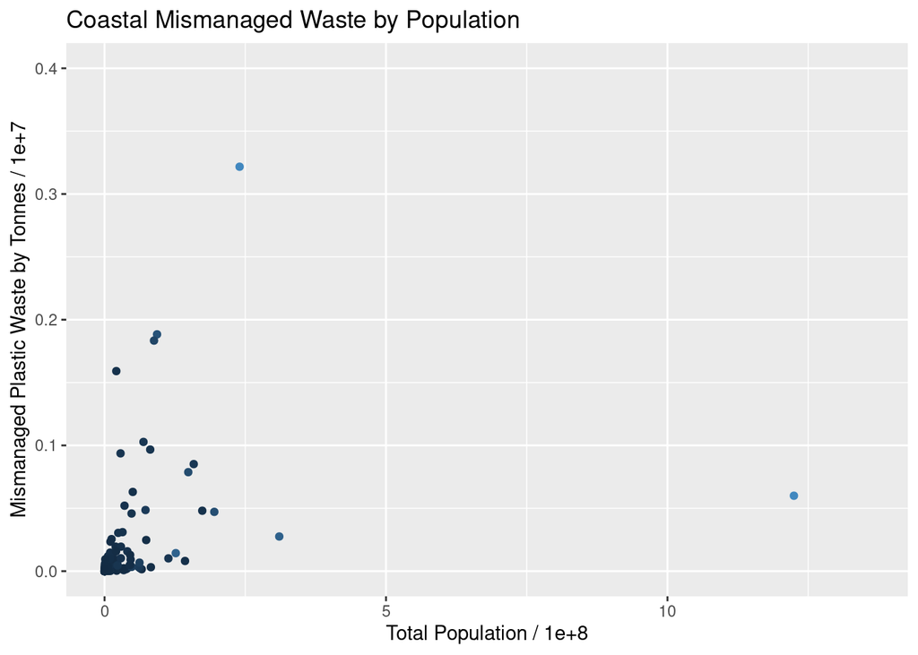

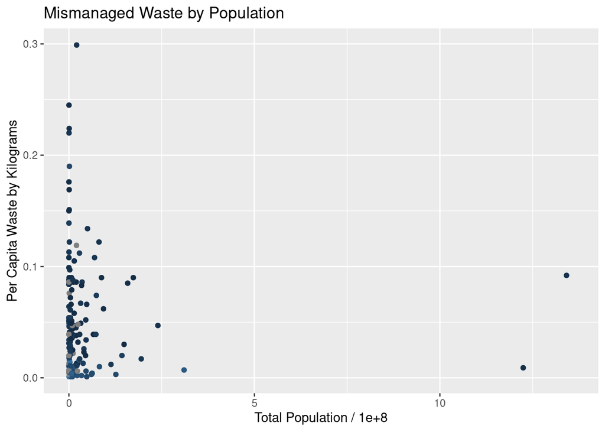

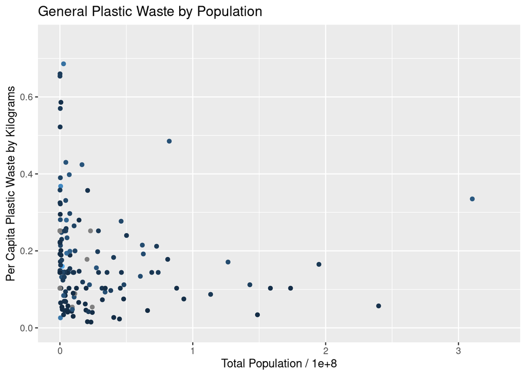

> These 3 scatterplots deomonstrate the relationship between population and 3 different plastic waste variables: `coastal`, `mismanaged`, and `general`. Despite correlations implied in the studies referenced, there seems to be no susceptible relation between these variables in this dataset. This suggests that there may be another factor influencing waste production.

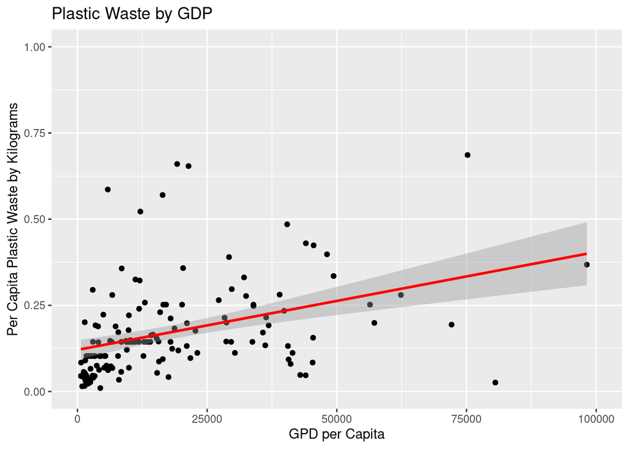

> Next, this regression model demonstrates the relation between `GPD` and `waste production`. The best-fit line suggests a slight positive correlation between the two variables, with greater inaccuracies with increasing values.

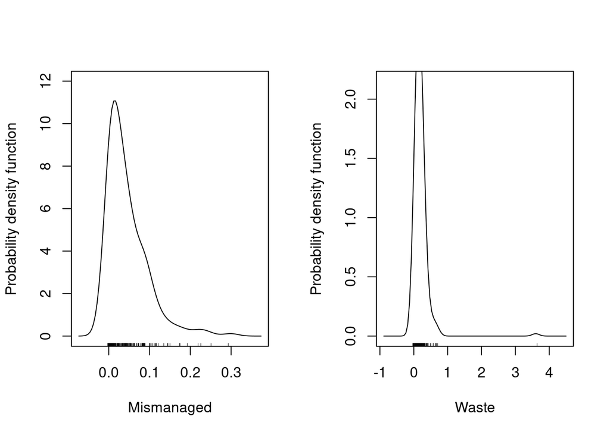

> These density plots represent the distribution of values of the variables `Mismanaged Waste` and `Plastic Waste`. While no distinct conclusions can be drawn from the plots, they provide a visualization of the difference in frequencies of these variables.

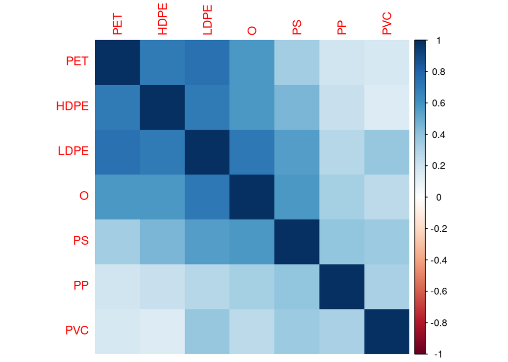

## 5 Discussion

Despite several questions brought in Section 1, little conclusions could be made from the data presented. One relation was found between `GPD` and `Plastic Waste`, however it being slight. It was expected to find strong correlation between population and various waste values, yet none was found. The results were ultimately surprising.

## 6 References

Kumar, A., Samadder, S. R., Kumar, N., & Singh, C. (2018). Estimation of the generation rate of different types of plastic wastes and possible revenue recovery from informal recycling. *Waste Management*, *79*, 781–790. https://doi.org/https://doi.org/10.1016/j.wasman.2018.08.045

Li, P., Wang, X., Su, M., Yang, J., & Zhang, W. (2021). Characteristics of plastic pollution in the environment: A review. *Bulletin of Environmental Contamination and Toxicology*, *107*(4), 577–584.

Mihai, F.-C., Gündoğdu, S., Markley, L. A., Olivelli, A., Khan, F. R., Gwinnett, C., Gutberlet, J., Reyna-Bensusan, N., Llanquileo-Melgarejo, P., Meidiana, C., Elagroudy, S., Ishchenko, V., Penney, S., Lenkiewicz, Z., & Molinos-Senante, M. (2021). Plastic pollution, waste management issues, and circular economy opportunities in rural communities. *Sustainability*, *14*(1), 20. https://doi.org/10.3390/su14010020

Obebe, S., & Adamu, A. (2020). Plastic pollution: Causes, effects and preventions. *Int J Eng Appl Sci Technol*, *4*(12), 85–95.

Schwarz, A. E., Ligthart, T. N., Boukris, E., & van Harmelen, T. (2019). Sources, transport, and accumulation of different types of plastic litter in aquatic environments: A review study. *Marine Pollution Bulletin*, *143*, 92–100. https://doi.org/https://doi.org/10.1016/j.marpolbul.2019.04.029

## Citation

BibTeX citation:

```
@online{andreas2023,
  author = {Lane Andreas},
  title = {PLASTIC {POLLUTION}},
  date = {2023-05-08},
  langid = {en},
  abstract = {This study examines the relationship between population
    and plastic waste, considering other potential causes if the initial
    hypothesis is disproven. By analyzing a comprehensive dataset and
    employing inferential statistical tests, the study investigates the
    complex dynamics of plastic pollution. The findings provide insights
    into the role of population size and other factors such as
    consumption patterns, waste management infrastructure, and economic
    development.}
}
```

For attribution, please cite this work as:

Lane Andreas. (2023, May 8). *PLASTIC POLLUTION*.